# Project: Medical Company Analysis

- Introduction
- Data Wrangling
- Exploratory Data Analysis
- Conclusions

## Introduction

A physician’s office wants to gain a better understanding of their patients and their probabilty of a no show appointment. The dataset shows the data associated with the medical office and details the clients information and whether or not they were a no show or not.

# Question

What measures can be taken to reduce the number of no-show patients?

# Understand

The office would like the know the following:  
1. What percentage of patients are a no show?  
2. Are text message reminders an effective way to reduce the amount of no shows?  
3. Which age group has the most amount of no shows?

By learning patient habits in regard to appointments and no shows, the physicians office is able to more effectively target their customers to decrease no shows which would increase revenue.

## Exploratory Data Analysis

The general goal of the report is to determine the most common reasons for no show appointments and any ways to reduce the number. The analysis will take a look at three factors: The use of text message reminders, no shows for various age groups, and no shows percentages for gender types.

Through this analysis, healthcare group will be able to effecietlvy create a marketing strategy to reduce the number of no shows.

### Research Question 1 (Are text message reminders effective?)

> The first thing that we will take a look at is the effectivness of text messages. We will explore the relationship between sending out a text message and the number of people who do not show up for their appointment. A general hypothesis is that by sending a text message reminder, it will reduce the number of no show appointments.

```python
# Since I'm going to be working with only certain columns, I'm dropping the unncessesary columns
research = medical.drop(columns = ['Neighbourhood','Hypertension','Diabetes','Alcoholism' ,'Handicap','ScheduledDay','AppointmentDay','Scholarship' ,'AppointmentID'])
research.head()
```

|  | Unnamed: 0 | PatientId | Gender | Age | SMS_received | No-show | Groups |
| --- | --- | --- | --- | --- | --- | --- | --- |
| 0 | 0 | 2.987250e+13 | F | 62 | 0 | No | Elder Adult |
| 1 | 1 | 5.589978e+14 | M | 56 | 0 | No | Elder Adult |
| 2 | 2 | 4.262962e+12 | F | 62 | 0 | No | Elder Adult |
| 3 | 3 | 8.679512e+11 | F | 8 | 0 | No | Infant |
| 4 | 4 | 8.841186e+12 | F | 56 | 0 | No | Elder Adult |

[output not shown]

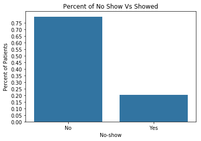

```python
r1 = research.shape[0]
maxr = research['No-show'].value_counts().max()
max_prop = maxr / r1
tick_props = np.arange(0, max_prop, 0.05)
tick_names = ['{:0.2f}'.format(v) for v in tick_props]

sb.countplot(data = research, x = 'No-show', color = base_color)
plt.yticks(tick_props * r1, tick_names)
plt.ylabel('Percent of Patients')
plt.title('Percent of No Show Vs Showed');
```

```python
#In this section, we will seperate the number of no shows into those who showed up for their appointment and those who were a no show

no_shows = research[research[('No-show')] == 'Yes']
showed = research[research[('No-show')] == 'No']
print('Quick Analysis')
print("There number of patients who did not show up for their appointment is:", len(no_shows))
print('The number of patients who showed up for their appointment is:', len(showed))
print('The percentage of patients who did not show up for their appointment is:',  round((len(no_shows) / len(showed)) * 100),'%')
print('The percentage of patients who showed up for their appointment is:',  round((1 - len(no_shows) / len(showed)) * 100),'%')
```

[output not shown]